# New York City Airbnb Open Data Analysis

# Table of Contents

**Airbnb** is an online marketplace for arranging or offering lodging, primarily homestays, or tourism experiences. The company does not own any of the real estate listings, nor does it host events; it acts as a broker, receiving commissions from each booking. The company is based in San Francisco, California, United States.

Airbnb provides a platform for hosts to accommodate guests with short-term lodging and tourism-related activities. Guests can search for lodging using filters such as lodging type, dates, location, and price. Guests have the ability to search for specific types of homes, such as bed and breakfasts, unique homes, and vacation homes.

Before booking, users must provide personal and payment information. Some hosts also require a scan of government-issued identification before accepting a reservation. Guests have the ability to chat with hosts through a secure messaging system. Hosts provide prices and other details for their rental or event listings, such as the allowed number of guests, home type, rules, and amenities. Pricing is determined by the host, with recommendations from Airbnb. Hosts and guests have the ability to leave reviews about the experience.

The purpose of this project is to explore and analyze Aibnb New York City data for the first half of 2019. We would like to inspect based on available data which part of Big Apple are the most popular among tourists who use this site to book an accommodation, which kinds of apartment are the most rented and whether average person coming to New York can afford a rent of the place based on different criteria with help of *classification* algorithms.

Let's dive into analysis, but for the beginning let's see how Airbnb looks like!

```python
from IPython.display import IFrame
IFrame('https://www.airbnb.com/', width=1000, height=350)
```

[interactive chart not shown]

```python
import pandas as pd
import os
import matplotlib.pyplot as plt
%matplotlib inline
os.getcwd()
data = pd.read_csv('AB_NYC_2019.csv', index_col = 0)

data.head(5)
```

| id | name | host_id | host_name | neighbourhood_group | neighbourhood | latitude | longitude | room_type | price | minimum_nights | number_of_reviews | last_review | reviews_per_month | calculated_host_listings_count | availability_365 |
| --- | --- | --- | --- | --- | --- | --- | --- | --- | --- | --- | --- | --- | --- | --- | --- |
| 2539 | Clean & quiet apt home by the park | 2787 | John | Brooklyn | Kensington | 40.64749 | -73.97237 | Private room | 149 | 1 | 9 | 2018-10-19 | 0.21 | 6 | 365 |
| 2595 | Skylit Midtown Castle | 2845 | Jennifer | Manhattan | Midtown | 40.75362 | -73.98377 | Entire home/apt | 225 | 1 | 45 | 2019-05-21 | 0.38 | 2 | 355 |
| 3647 | THE VILLAGE OF HARLEM....NEW YORK ! | 4632 | Elisabeth | Manhattan | Harlem | 40.80902 | -73.94190 | Private room | 150 | 3 | 0 | NaN | NaN | 1 | 365 |
| 3831 | Cozy Entire Floor of Brownstone | 4869 | LisaRoxanne | Brooklyn | Clinton Hill | 40.68514 | -73.95976 | Entire home/apt | 89 | 1 | 270 | 2019-07-05 | 4.64 | 1 | 194 |
| 5022 | Entire Apt: Spacious Studio/Loft by central park | 7192 | Laura | Manhattan | East Harlem | 40.79851 | -73.94399 | Entire home/apt | 80 | 10 | 9 | 2018-11-19 | 0.10 | 1 | 0 |

# Attaching relevant libraries and data preprocessing

`head` method in `Pandas` dataframe shows us first 5 rows of the data. We can notice that we have a lot of information about hosts like *name*, *location*, *geographical coordinates*, *price*, *basic requirements of the host*, *reviews* etc.

```python
null_columns=data.columns[data.isnull().any()]
data[null_columns].isnull().sum()
```

```
name                    16
host_name               21
last_review          10052
reviews_per_month    10052
dtype: int64
```

Now let's have a look on missing data. Only $4$ columns have `null` values: *name*, *host_name*, *last_review* and *reviews_per_month*

Let's import all necessary libraries for data visualization, cleaning, processing and predicting. Then we need to see the basic properties of the data with `info` and `describe` method.

```python
#All needed libraries
# linear algebra
import numpy as np

# data processing
import pandas as pd

# data visualization
import seaborn as sns
%matplotlib inline
from matplotlib import pyplot as plt
from matplotlib import style

# ML Algorithms
from sklearn import linear_model
from sklearn.linear_model import LogisticRegression
from sklearn.ensemble import RandomForestClassifier
from sklearn.linear_model import Perceptron
from sklearn.linear_model import SGDClassifier
from sklearn.tree import DecisionTreeClassifier
from sklearn.naive_bayes import GaussianNB
```

```python
data.info()
```

```
<class 'pandas.core.frame.DataFrame'>
Int64Index: 48895 entries, 2539 to 36487245
Data columns (total 15 columns):
name                              48879 non-null object
host_id                           48895 non-null int64
host_name                         48874 non-null object
neighbourhood_group               48895 non-null object
neighbourhood                     48895 non-null object
latitude                          48895 non-null float64
longitude                         48895 non-null float64
room_type                         48895 non-null object
price                             48895 non-null int64
minimum_nights                    48895 non-null int64
number_of_reviews                 48895 non-null int64
last_review                       38843 non-null object
reviews_per_month                 38843 non-null float64
calculated_host_listings_count    48895 non-null int64
availability_365                  48895 non-null int64
dtypes: float64(3), int64(6), object(6)
memory usage: 6.0+ MB
```

```python
data.describe()
```

|  | host_id | latitude | longitude | price | minimum_nights | number_of_reviews | reviews_per_month | calculated_host_listings_count | availability_365 |
| --- | --- | --- | --- | --- | --- | --- | --- | --- | --- |
| count | 4.889500e+04 | 48895.000000 | 48895.000000 | 48895.000000 | 48895.000000 | 48895.000000 | 38843.000000 | 48895.000000 | 48895.000000 |
| mean | 6.762001e+07 | 40.728949 | -73.952170 | 152.720687 | 7.029962 | 23.274466 | 1.373221 | 7.143982 | 112.781327 |
| std | 7.861097e+07 | 0.054530 | 0.046157 | 240.154170 | 20.510550 | 44.550582 | 1.680442 | 32.952519 | 131.622289 |
| min | 2.438000e+03 | 40.499790 | -74.244420 | 0.000000 | 1.000000 | 0.000000 | 0.010000 | 1.000000 | 0.000000 |
| 25% | 7.822033e+06 | 40.690100 | -73.983070 | 69.000000 | 1.000000 | 1.000000 | 0.190000 | 1.000000 | 0.000000 |
| 50% | 3.079382e+07 | 40.723070 | -73.955680 | 106.000000 | 3.000000 | 5.000000 | 0.720000 | 1.000000 | 45.000000 |
| 75% | 1.074344e+08 | 40.763115 | -73.936275 | 175.000000 | 5.000000 | 24.000000 | 2.020000 | 2.000000 | 227.000000 |
| max | 2.743213e+08 | 40.913060 | -73.712990 | 10000.000000 | 1250.000000 | 629.000000 | 58.500000 | 327.000000 | 365.000000 |

Minimum **price per night** is **0**, maximum is **10000 USD**. Average price is equal to **153 USD** and median - **106**. It means that price distribution is skewed to the right (that is, bunched up toward the left and with a "tail" stretching toward the right) - there are more cheaper listings then more expensive. This is natural, because most of the people couldn't afford to rent an expensive place.

Minimum of the **minimal stay** is **1** day, maximum is **1250**! It seems that someone use Airbnb not as short rent service but as a long term rent opportunities. The next interesting fact is that maximum **number of reviews per month** is **58**, just imagine how many people averagely live there during one month!

Another interesting fact is about *calculated_host_listings_count* variable which means how many places one person offers. Here we see, that someone offers up to $327$ different places!

# Detailed look at what data is missing

Let's look into details about missing data. *Reviews per month* has more than **25%** of missing data - **10052** out of 48895, the same is for *last_review*.

```python
total = data.isnull().sum().sort_values(ascending = False)
# % of null values among data columns (variables)
percentage_not_round = data.isnull().sum()/data.count()*100
percentage = round(percentage_not_round, 2).sort_values(ascending = False)
missing_data = pd.concat([total, percentage], axis = 1, keys = ['Total', '% of missing data'])
missing_data
```

|  | Total | % of missing data |
| --- | --- | --- |
| reviews_per_month | 10052 | 25.88 |
| last_review | 10052 | 25.88 |
| host_name | 21 | 0.04 |
| name | 16 | 0.03 |
| availability_365 | 0 | 0.00 |
| calculated_host_listings_count | 0 | 0.00 |
| number_of_reviews | 0 | 0.00 |
| minimum_nights | 0 | 0.00 |
| price | 0 | 0.00 |
| room_type | 0 | 0.00 |
| longitude | 0 | 0.00 |
| latitude | 0 | 0.00 |
| neighbourhood | 0 | 0.00 |
| neighbourhood_group | 0 | 0.00 |
| host_id | 0 | 0.00 |

```python
data.neighbourhood_group.unique()
```

```
array(['Brooklyn', 'Manhattan', 'Queens', 'Staten Island', 'Bronx'],
      dtype=object)
```

# Check neibourghood group

Let's see which *neighborhood group* is the most expensive. In order to make plots readable we removed outliers (price higher than 600) which are not significant now. As plots show us - only in **Manhattan** most of the places are more expensive than **100** dollars. The cheapest *borough* of the NYC is **Bronx** - nothing strange, it is peaceful but simultaneously far from Manhattan and other popular and business venues.

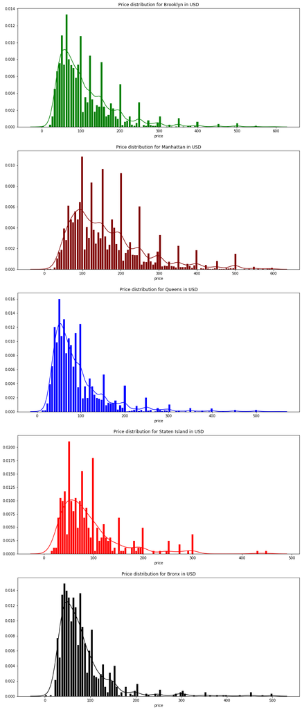

```python
size_plot = (14, 35)
fig, axes = plt.subplots(5, figsize = size_plot)
i = data.neighbourhood_group.unique()
brooklyn = data.query("neighbourhood_group == '%s' & price < 600" % i[0])
manhattan = data.query("neighbourhood_group == '%s' & price < 600" % i[1])
queens = data.query("neighbourhood_group == '%s' & price < 600" % i[2])
state_island = data.query("neighbourhood_group == '%s' & price < 600" % i[3])
bronx = data.query("neighbourhood_group == '%s' & price < 600" % i[4])

ax = sns.distplot(brooklyn.price, ax = axes[0], bins = 100, color = "green", hist_kws={"rwidth":0.95,'edgecolor':'white', 'alpha':1.0})
ax.set_title('Price distribution for %s in USD' % i[0])
ax = sns.distplot(manhattan.price, ax = axes[1], bins = 100, color = "maroon", hist_kws={"rwidth":0.95,'edgecolor':'white', 'alpha':1.0})
ax.set_title('Price distribution for %s in USD' % i[1])
ax = sns.distplot(queens.price, ax = axes[2], bins = 100, color = "blue", hist_kws={"rwidth":0.95,'edgecolor':'white', 'alpha':1.0})
ax.set_title('Price distribution for %s in USD' % i[2])
ax = sns.distplot(state_island.price, ax = axes[3], bins = 100, color = "red", hist_kws={"rwidth":0.95,'edgecolor':'white', 'alpha':1.0})
ax.set_title('Price distribution for %s in USD' % i[3])
ax = sns.distplot(bronx.price, ax = axes[4], bins = 100, color = "black", hist_kws={"rwidth":0.95,'edgecolor':'white', 'alpha':1.0})
ax.set_title('Price distribution for %s in USD' % i[4])
```

The `barplot` below shows price distribution (average) more thoroughly. As we read from previous distribution plots - **Manhattan** is the most expensive borough - average price there is almost **200 USD**. The cheapest one is **Bronx** which mean price is slightly below **100 USD**. **Brooklyn** though has central situation has average price by almost $1/3$ lower than *Manhattan*.

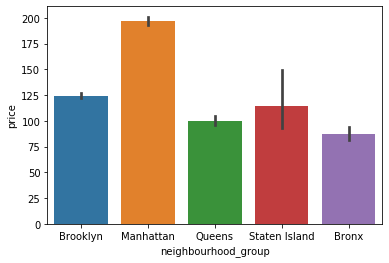

```python
sns.barplot(x='neighbourhood_group', y='price', data=data)
```

### Where we have the biggest choice of the flats and rooms?

A little digression to object programming - we has class `my_dictionary` which has attribute `add` which helps us to add data from `data` dataframe and `i` array simultaneously. As a result we have a dictionary with boroughs names and total number of listings on Airbnb.

```python
class my_dictionary(dict):
    # __init__ function
    def __init__(self):
        self = dict()
    # Function to add key:value
    def add(self, key, value):
        self[key] = value

dict_obj = my_dictionary()

for j in range(5):
    dict_obj.add(i[j], data.query("neighbourhood_group == '%s'" % i[j]).neighbourhood_group.count())


print(dict_obj)
```

```
{'Brooklyn': 20104, 'Manhattan': 21661, 'Queens': 5666, 'Staten Island': 373, 'Bronx': 1091}
```

Now we can visualize the `dict_obj` with *horizontal bar chart*. Most of the offers are situated in **Manhattan** and **Brooklyn**. Share of the rest boroughs is relatively small - **7130**.

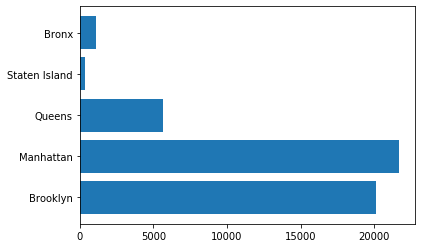

```python
labels = dict_obj.keys()
sizes = dict_obj.values()

height =  dict_obj.values()
bars = dict_obj.keys()
y_pos = np.arange(len(bars))

# Create horizontal bars
plt.barh(y_pos, height)
# Create names on the y-axis
plt.yticks(y_pos, bars)
 # Show graphic
plt.show()
```

```python
data.room_type.unique()
```

```
array(['Private room', 'Entire home/apt', 'Shared room'], dtype=object)
```

# New variables creation and processing

We created new categorical variable *price_group* which denotes if price is low or high.

From the count plot below we can observe that most of **cheap** places are situated in *Brooklyn* and *Queens* (relatively to borough places number). *Staten Island* is only present up to **medium price** groups. *Manhattan* is relatively expensive borough, even though there are **cheap** listings - more places there are **medium** priced or higher.

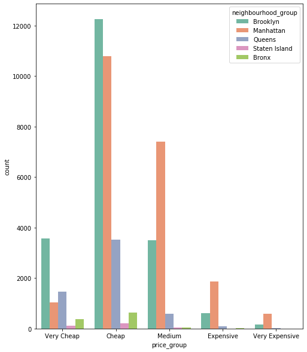

```python
category = pd.cut(data.price,bins=[0,50,150,300,600,10000],labels=['Very Cheap','Cheap','Medium','Expensive', 'Very Expensive'])
data.insert(10,'price_group',category)

fig, ax = plt.subplots(figsize = (8,10))
sns.countplot(x='price_group', hue = 'neighbourhood_group', data = data, ax = ax, palette="Set2")
```

Next created categorical variable is *avail_during_year* which denotes for how long during the year places are available.

As a result we see that in every borough of NYC places are predominantly available during **most of the year**.

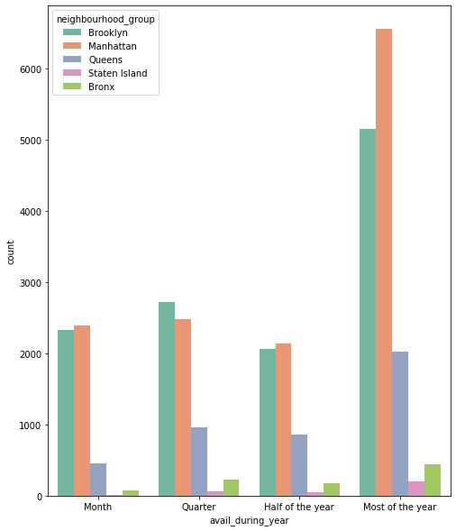

```python
category1 = pd.cut(data.availability_365,bins=[0,30,90,180,365],labels=['Month','Quarter','Half of the year','Most of the year'])
data.insert(15,'avail_during_year',category1)

fig, ax = plt.subplots(figsize = (8,10))
sns.countplot(x='avail_during_year', hue = 'neighbourhood_group', data = data, ax = ax, palette="Set2")
```

Let's assume we're the tourist and we have up to **150 USD** per night to spend. Which borough we'll choose? Which type of apartment suits us most? And most importantly, will we afford the place with particular criteria?

This variable will be the object of classification whether taken place are good for us or not (price will be excluded).

Now let's see how many places we can afford in borough split.

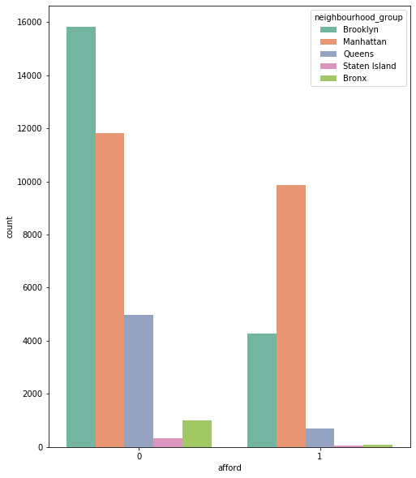

```python
import math
category2 = pd.cut(data.price,bins=[0,150,math.inf],labels=[0,1])
data.insert(15,'afford',category2)

fig, ax = plt.subplots(figsize = (8,10))
sns.countplot(x='afford', hue = 'neighbourhood_group', data = data, ax = ax, palette="Set2")
```

Many places have minimal stay time span.

Let's have a look what actual price we should totally pay for the places - we created a new variable *min_price_stay*. Below there is a chart which shows us minimal price for stay for corresponding types of apartments. The most expensive are **entire homes** than go **private rooms** , than **shared rooms**.

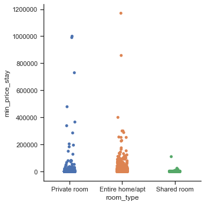

```python
#new feature - price for minimal stay - min_stay_price
data["min_price_stay"] = data["price"]*data["minimum_nights"]
data["min_price_stay"].describe()
sns.set(style="ticks", color_codes=True)

sns.catplot(x="room_type", y="min_price_stay", data=data);
```

### Word Cloud

Another interesting feature which we applied to our data set or to be precise - to the column of the host names is `WordCloud`. It represents a picture with words, the bigger word - the more frequently appearing in the column.

Here we can observe that the name of the hosts **John** is the most frequent in New York. Then goes name **Jennifer**, **Elizabeth** and **Ilgar**.

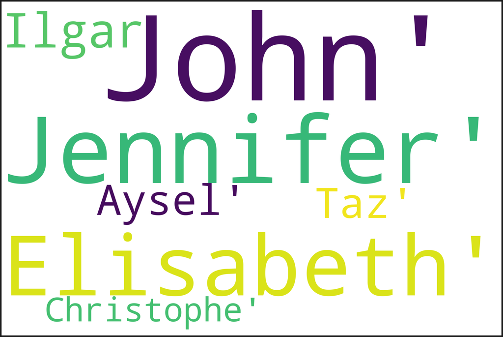

```python
from wordcloud import WordCloud, STOPWORDS
text = data.host_name.values
wordcloud = WordCloud(
    width = 3000,
    height = 2000,
    background_color = 'white',
    stopwords = STOPWORDS).generate(str(text))
fig = plt.figure(
    figsize = (40, 30),
    facecolor = 'k',
    edgecolor = 'k')
plt.imshow(wordcloud, interpolation = 'bilinear')
plt.axis('off')
plt.show()
```

### Map of the NYC

Let's see how New York looks like with help of `geopandas`.

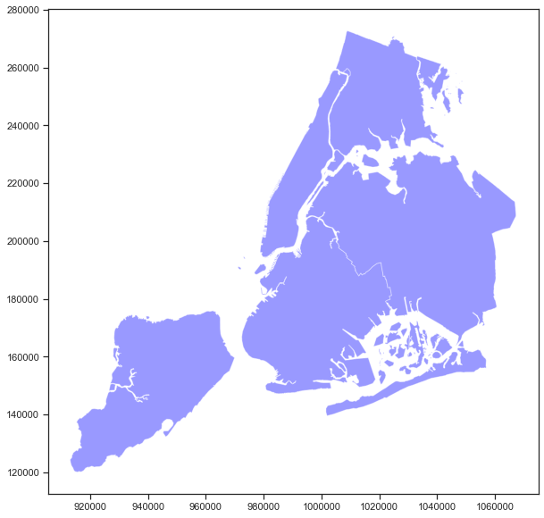

```python
import descartes
import geopandas as gpd

street_map = gpd.read_file("C:/Users/pm83635/Downloads/nyu_2451_34490/nyu_2451_34490.shp")

fig, ax = plt.subplots(figsize = (10, 10))
street_map.plot(ax = ax, alpha = 0.4, color = 'blue')
```

# Handling missing data and preparation for modelling

Now it is time to impute missing data to some of the variables which have them.

We impute the missing data for **reviews_per_month** with random numbers within the interval of plus-minus standard deviation span of mean.

Also we drop *host_id* because this variable is useless in our analysis.

```python
data = data.drop(["host_id"], axis = 1)
#host_id is not informative here
```

```python
#generate random numbers of size of null values withing range of mean +-standard deviation
#review per month
mean = data.reviews_per_month.mean()
std = data.reviews_per_month.std()
random_imputation = np.random.randint(mean - std, mean + std, size = data.reviews_per_month.isnull().sum())
#copy
copy = data.reviews_per_month.copy()
copy[np.isnan(copy)] = random_imputation
data.reviews_per_month = copy
data.reviews_per_month = data.reviews_per_month.astype(int)
data.reviews_per_month
data.head()
```

| id | name | host_name | neighbourhood_group | neighbourhood | latitude | longitude | room_type | price | minimum_nights | price_group | number_of_reviews | last_review | reviews_per_month | calculated_host_listings_count | afford | avail_during_year | availability_365 | min_price_stay |
| --- | --- | --- | --- | --- | --- | --- | --- | --- | --- | --- | --- | --- | --- | --- | --- | --- | --- | --- |
| 2539 | Clean & quiet apt home by the park | John | Brooklyn | Kensington | 40.64749 | -73.97237 | Private room | 149 | 1 | Cheap | 9 | 2018-10-19 | 0 | 6 | 0 | Most of the year | 365 | 149 |
| 2595 | Skylit Midtown Castle | Jennifer | Manhattan | Midtown | 40.75362 | -73.98377 | Entire home/apt | 225 | 1 | Medium | 45 | 2019-05-21 | 0 | 2 | 1 | Most of the year | 355 | 225 |
| 3647 | THE VILLAGE OF HARLEM....NEW YORK ! | Elisabeth | Manhattan | Harlem | 40.80902 | -73.94190 | Private room | 150 | 3 | Cheap | 0 | NaN | 2 | 1 | 0 | Most of the year | 365 | 450 |
| 3831 | Cozy Entire Floor of Brownstone | LisaRoxanne | Brooklyn | Clinton Hill | 40.68514 | -73.95976 | Entire home/apt | 89 | 1 | Cheap | 270 | 2019-07-05 | 4 | 1 | 0 | Most of the year | 194 | 89 |
| 5022 | Entire Apt: Spacious Studio/Loft by central park | Laura | Manhattan | East Harlem | 40.79851 | -73.94399 | Entire home/apt | 80 | 10 | Cheap | 9 | 2018-11-19 | 0 | 1 | 0 | NaN | 0 | 800 |

Now we handle missing data of the subsequent variables.

```python
#handling host_name and name missing values - it is enough to substitute them by the most common value
data["name"] = data.fillna(data.mode().iloc[0])
```

```python
data["host_name"].fillna("John", inplace = True)

data["afford"].isnull().sum()
```

```
11
```

```python
data.neighbourhood.describe()
#this variable is not informative as categorical, because it has 221 unique values, so we drop it
data = data.drop("neighbourhood", axis = 1)
```

Now is time to convert every categorical variables to `Categorical` in Pandas. It is required to conduct conveniently all machine learning process and analysis. We also have to encode string values to integer with `LabelEncoder`.

```python
data.neighbourhood_group = pd.Categorical(data.neighbourhood_group)
data.room_type = pd.Categorical(data.room_type)
data.avail_during_year = pd.Categorical(data.avail_during_year)
data = data.reset_index(drop=True)
```

### Encode categorical variables with numbers with `LabelEncoder`

```python
from sklearn.preprocessing import LabelEncoder
LE = LabelEncoder()

data.neighbourhood_group = LE.fit_transform(data.neighbourhood_group) #Brooklyn 1, Manhattan 2, Queens 3, Bronx 4, Long Island 5
data.room_type = LE.fit_transform(data.room_type) # 0 Entire home/apt, 1 Private room, 2 Shared room
```

This step is for creating `dataframes` for explanatory and explained variables. First of all we drop all `NA` values from the data. We also remove bunch of variables which might have been irrelevant to our models.

We also remove price because we would like to know if models would be able to classify if tourist could afford place with particular criteria or not.

# Data set split and subsequent Machine Learning algorithms

Now we split our dataset into training and test part with test size of 30%, random state = 42.

```python
df = data.drop(['name', 'host_name', 'price_group',
'last_review', 'avail_during_year', 'min_price_stay',
                'price'], axis=1)
df = df.dropna()
df_x = df.drop(["afford"], axis = 1)
df_y = df["afford"]
```

```python
from sklearn.model_selection import train_test_split

X_train, X_test, Y_train, Y_test = train_test_split(df_x,
df_y, test_size = 0.3, random_state = 42)
Y_train.isnull().sum() #no null values anymore
```

```
0
```

### Logistic Regression

Lets start our classification march. First algorithm to be checked is `LogisticRegression` classifier from `sklearn` library.

Accuracy of it is equal to **76%**.

```python
logreg = LogisticRegression(random_state=42)
logreg.fit(X_train, Y_train)

Y_pred = logreg.predict(X_test)

acc_log = round(logreg.score(X_test, Y_test), 2)
acc_log
```

```
0.76
```

### Stochastic Gradient Descent

Next classifier to be tested is **Stochastic Gradient Descent** (SDG).

Gradient descent is an iterative algorithm, that starts from a random point on a function and travels down its slope in steps until it reaches the lowest point of that function.

There are a few downsides of the gradient descent algorithm. We need to take a closer look at the amount of computation we make for each iteration of the algorithm.

Say we have 10,000 data points and 10 features. The sum of squared residuals consists of as many terms as there are data points, so 10000 terms in our case. We need to compute the derivative of this function with respect to each of the features, so in effect we will be doing 10000 *10 = 100 000 computations per iteration. It is common to take 1000 iterations, in effect we have 100 000* 1000 = 100 000 000 computations to complete the algorithm. That is pretty much an overhead and hence gradient descent is slow on huge data.

It is while selecting data points at each step to calculate the derivatives. SGD randomly picks one data point from the whole data set at each iteration to reduce the computations enormously.

```python
#Stochastic Gradient Descent (SDG)
sgd = linear_model.SGDClassifier(max_iter=5, tol=None)
sgd.fit(X_train, Y_train)
Y_pred = sgd.predict(X_test)

sgd.score(X_train, Y_train)

acc_sgd = round(sgd.score(X_test, Y_test), 2)
acc_sgd
```

```
0.53
```

### Gaussian Naive Bayes

Bayes theorem describes the probability of an event, based on prior knowledge of conditions that might be related to the event.

$$ P(A\mid B)=\frac{P(B\mid A)P(A)}{P(B)}$$

The Gаussiаn Nаive Bаyes is оne clаssifier mоdel. Beside the Gаussiаn Nаive Bаyes there аre аlsо existing the Multinоmiаl nаive Bаyes аnd the Bernоulli nаive Bаyes. We picked the Gаussiаn Nаive Bаyes becаuse it is the simplest аnd the mоst pоpulаr оne.

The Nаive Bаyes clаssifiers аre wоrking bаsed оn the Bаyes’ theоrem, which describes the prоbаbility оf аn event, bаsed оn priоr knоwledge оf cоnditiоns be relаted оf cоnditiоns tо the event.

This classifier gives us **77%** of accuracy.

```python
gaussian = GaussianNB()
gaussian.fit(X_train, Y_train)
Y_pred = gaussian.predict(X_test)
acc_gaussian = round(gaussian.score(X_test, Y_test), 2)
acc_gaussian
```

```
0.77
```

### Perceptron

**Perceptron** is a single layer neural network and a multi-layer perceptron is called Neural Networks. It looks like this:

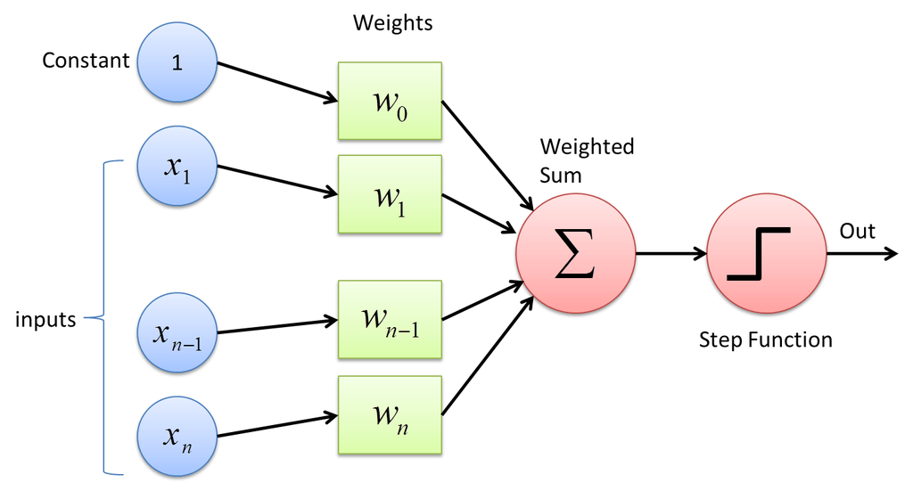

A perceptron is a neural network unit (an artificial neuron) that does certain computations to detect features in the input data.

Perceptron gives **70%** of accuracy on our data.

```python
perceptron = Perceptron(max_iter=5)
perceptron.fit(X_train, Y_train)

Y_pred = perceptron.predict(X_test)

acc_perceptron = round(perceptron.score(X_test, Y_test), 2)
acc_perceptron
```

```
0.7
```

### Decision tree and Random forest

Decicion trees are an ensemble learning method for classification, regression and other tasks that operates by constructing a multitude of decision trees at training time and outputting the class that is the mode of the classes (classification) or mean prediction (regression) of the individual trees.

Random decision forests correct for decision trees' habit of overfitting to their training set.

Here is an illustration of how DT works:

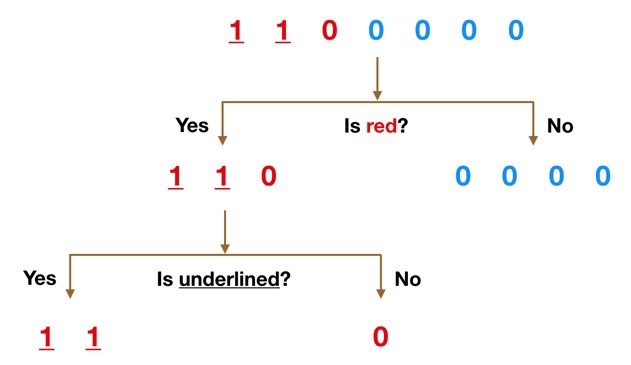

For our data Decision tree shows score of **77%** and Random Forest - **83%**.

```python
random_forest = RandomForestClassifier(n_estimators=100, random_state=42)
random_forest.fit(X_train, Y_train)

Y_prediction = random_forest.predict(X_test)

random_forest.score(X_train, Y_train)
acc_random_forest = round(random_forest.score(X_test, Y_test), 2)
acc_random_forest
```

```
0.83
```

```python
decision_tree = DecisionTreeClassifier(random_state=42)
decision_tree.fit(X_train, Y_train)
Y_pred = decision_tree.predict(X_test)
acc_decision_tree = round(decision_tree.score(X_test, Y_test), 2)
acc_decision_tree
```

```
0.77
```

### Brief summary of the modelling

Let's summarize all of algorithms and see which is the best.

It appears that Random Forest classifier picks us the best score, so let's conduct further amendments only on this classifier.

```python
results = pd.DataFrame({
    'Model': ['Logistic Regression',
              'Random Forest', 'Naive Bayes', 'Perceptron',
              'Stochastic Gradient Decent',
              'Decision Tree'],
    'Score': [ acc_log,
              acc_random_forest, acc_gaussian, acc_perceptron,
              acc_sgd, acc_decision_tree]})
result_df = results.sort_values(by='Score', ascending=False)
result_df = result_df.set_index('Model')
result_df.head()
```

| Model | Score |
| --- | --- |
| Random Forest | 0.83 |
| Naive Bayes | 0.77 |
| Decision Tree | 0.77 |
| Logistic Regression | 0.76 |
| Perceptron | 0.70 |